# 04_segmentation_features

Arthur de Grandpré

05 feb 2021

# Intro

This is the fourth script of the Open HRRS W2 workflow for open source high resolution remote sensing of vegetation cover optically complex waters.

This script generates image segmentation as required for all future steps. As of February 2021, segmentation will be performed on spectral bands only.

Based on the results of this script, land and water can be masked for stripe and glint corrections, or scenes can be directly classified if those corrections are not necessary.

# 1. Setting up the R environment

## 1.1. Libraries

First, load the required libraries. They can be installed using the *install.packages(“package.name”)* function.

```r
rm(list=ls()) ; gc()
```

```
##          used (Mb) gc trigger (Mb) max used (Mb)
## Ncells 407435 21.8     844724 45.2   638751 34.2
## Vcells 743308  5.7    8388608 64.0  1632880 12.5
```

```r
library(raster)
library(tidyverse)
library(sf)
library(sp)
library(rgdal)
```

## 1.2. Inputs / Outputs

```r
#OTB setup
otb.path  = "C:\\OTB-7.2.0-Win64\\bin" ### according to installation path and version (must be adjusted and use the double backslash!)

#input
boa_input = dir("C:/Users/Arthur/Documents/rscripts/Open_HRRS_W2/data/work/destripe_output/",full.names=T,pattern=".tif$") # Relative paths NOT ACCEPTED because of cmd call
MUL_input = boa_input[str_detect(boa_input, "MUL")]

#output
segmentation_output = paste0("C:/Users/Arthur/Documents/rscripts/Open_HRRS_W2/data/work/segmentation_output/") # Relative paths NOT ACCEPTED because of cmd call
features_output = paste0(segmentation_output,"/features/")
```

create the directories

```r
for(i in c(segmentation_output,features_output)){
  if(file.exists(i)){}else{
    dir.create(i)}
}
```

## 1.3. Define functions

Image segmentation is used to delineate objects within an image, generating polygons from a raster. In this case, we want to use an algorithm able to process large images with a large amount of layers. For this application, we will use Orfeo Toolbox’s MeanShift segmentation, which can process rapidly very large amounts of multi-band data in an opensource software.

Those resulting polygons will then be used to classify the image based on object properties instead of pixel values.

Let’s define the segmentation function call to OTB

```r
meanshift.segm <- function(raster.in = "",
                           out.path  = "",
                           name      = "",
                           filter.meanshift.spatialr = "5",   #default 5
                           filter.meanshift.ranger   = "0.0025",  #default 15 (0.0025 good for 2009, 0.001/0.0015 good for 2019)
                           filter.meanshift.thres    = "0.001", #default 0.1
                           filter.meanshift.maxiter  = "100", #default 100
                           filter.meanshift.minsize  = "5"  #default 100
                           ){

# Set configuration
conf <- paste("-in",raster.in,"-filter meanshift","-filter.meanshift.spatialr",filter.meanshift.spatialr,
                "-filter.meanshift.ranger",filter.meanshift.ranger,"-filter.meanshift.thres",filter.meanshift.thres,
                "-filter.meanshift.maxiter",filter.meanshift.maxiter,"-filter.meanshift.minsize",filter.meanshift.minsize,
                "-mode vector","-mode.vector.out",paste0(out.path,"/",name,".shp"))

  shell(paste("pushd ",otb.path,"&& otbcli_Segmentation ",conf))

write.table(x = conf,file = paste(out.path,"/",name,"_conf.txt",sep=""),row.names = F, col.names = F)
}
```

For a better classification, additionnal features can be added to the image, such as texture, local statistics and edge extractions. All those layers can be used as additionnal when classifying objects.

Let’s define the feature extraction function using Orfeo toolbox’s command line interface

```r
feature.HaralickTextureExtraction <- function(
                           raster.in = "",
                           out.path  = "",
                           name      = "",
                           channel = "1",   #default 1, selected channel index in input image
                           texture   = "simple",  #default simple, also available "advanced" or "higher"
                           parameters.min = "0", #input image minimum value
                           parameters.max = "1", #input image maximum value
                           parameters.xrad = "2", #xradius in pixels
                           parameters.yrad = "2", #yradisu in pixels
                           parameters.xoff = "1", #xoffset in pixels
                           parameters.yoff = "1", #yoffset in pixels
                           parameters.nbbin = "8" # bins per axis of histogram

                           ){

# Set configuration
conf <- paste("-RAM ",otb.ramlimit,
              "-in",raster.in,
              "-channel",channel,
              "-texture",texture,
              "-parameters.min",parameters.min,
              "-parameters.max",parameters.max,
              "-parameters.xrad",parameters.xrad,
              "-parameters.yrad",parameters.yrad,
              "-parameters.xoff",parameters.xoff,
              "-parameters.yoff",parameters.yoff,
              "-parameters.nbbin",parameters.nbbin,
              "-out",paste0(out.path,"/",name)
              )

  shell(paste("pushd ",otb.path,"&& otbcli_HaralickTextureExtraction ",conf))

write.table(x = conf,file = paste(out.path,"/",name,"_conf.txt",sep=""),row.names = F, col.names = F)
}
```

# 2. Segmentation

Segmentation parameters will greatly affect the segmentation quality. If segmentation quality seems bad after visual validation, it is possible to change the parameters in the following chunk. The current values are based on simple tweaking and visual cues. **Eventually**, maybe use SegOptim for optimization of segmentation parameters https://www.sciencedirect.com/science/article/abs/pii/S0303243418303556.

The output from this section is a simple shapefile

```r
for(i in seq_along(MUL_input)){

  meanshift.segm(filter.meanshift.spatialr = "5",      # default 5
               filter.meanshift.ranger   = "0.0015",  # default 15 # low for 2019
               filter.meanshift.thres    = "0.001",  # default 0.1
               filter.meanshift.maxiter  = "100",    # default 100
               filter.meanshift.minsize  = "5",     # default 100
               raster.in = gsub("/","\\\\",MUL_input[i]),
               out.path  = gsub("/","\\\\",segmentation_output),
               name      = str_split(gsub(".*/","",MUL_input[i]),"\\.")[[1]][1])

}
```

## visual validation

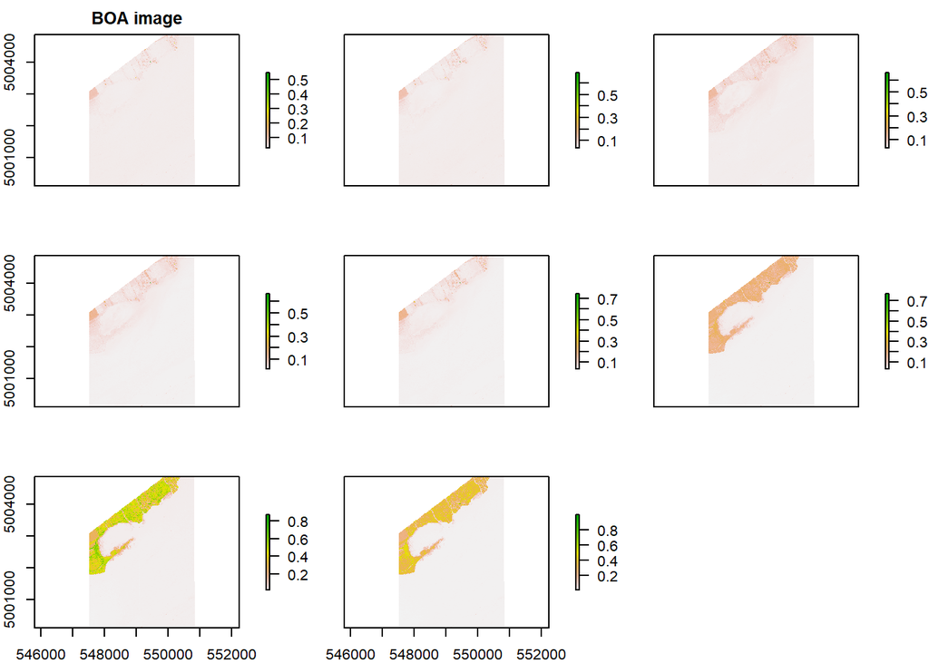

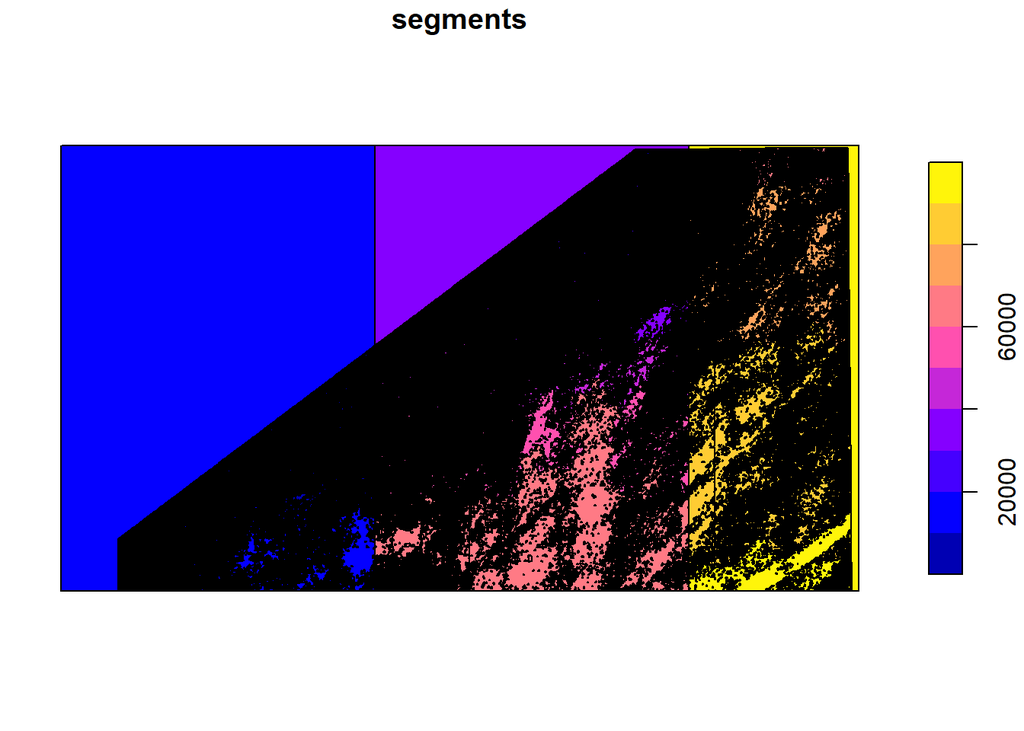

```r
final = dir(segmentation_output, full.names = T, pattern=".shp$")

plot(brick(MUL_input[1]), main = "BOA image"); plot(st_read(final[1]), main = "segments")
```

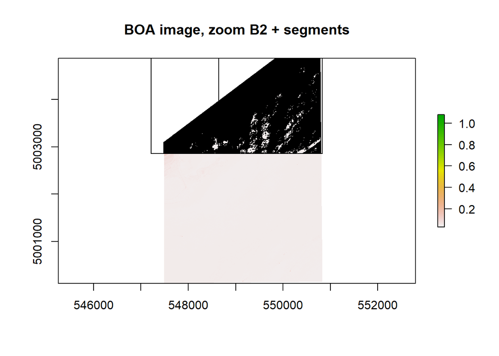

```r
plot(brick(MUL_input[1])[[2]], main = "BOA image, zoom B2 + segments", xlim=c(664500,665000),ylim=c(5111500,5112000)); plot(st_geometry(st_read(final[1])), main = "segments",add=T, xlim=c(664500,665000),ylim=c(5111500,5112000))
```

# 3. feature extraction

When calling the functions, slightly different calls will be made based on whether the image has 4 or 8 bands in order to use the NIR band. Edge extraction and local statistics have been removed from the workflow since they were unreliable.

```r
if(dir.exists(paste0(features_output,"haralick"))){}else{
  dir.create(paste0(features_output,"haralick"))
}

for(i in seq_along(MUL_input)){
# i=1

  r = brick(MUL_input[i])

otb.ramlimit = 16000

  if(nlayers(r)==8){
feature.HaralickTextureExtraction(
                           raster.in = gsub("/","\\\\",MUL_input[i]),
                           out.path  = paste0(gsub("/","\\\\",features_output),"haralick"),
                           name      = paste0("n_ht_",str_split(gsub(".*/","",MUL_input[i]),"\\.")[[1]][1]),
                           channel = "8",   #default 1, selected channel index in input image
                           texture   = "simple",  #default simple, also available "advanced" or "higher"
                           parameters.min = "0", #input image minimum value
                           parameters.max = "1", #input image maximum value
                           parameters.xrad = "5", #xradius in pixels
                           parameters.yrad = "5", #yradisu in pixels
                           parameters.xoff = "10", #xoffset in pixels
                           parameters.yoff = "10", #yoffset in pixels
                           parameters.nbbin = "64" # bins per axis of histogram
                           )
  } else {
feature.HaralickTextureExtraction(
                           raster.in = gsub("/","\\\\",MUL_input[i]),
                           out.path  = paste0(gsub("/","\\\\",features_output),"haralick"),
                           name      = paste0("n_ht_",str_split(gsub(".*/","",MUL_input[i]),"\\.")[[1]][1]),
                           channel = "4",   #default 1, selected channel index in input image
                           texture   = "simple",  #default simple, also available "advanced" or "higher"
                           parameters.min = "0", #input image minimum value
                           parameters.max = "1", #input image maximum value
                           parameters.xrad = "5", #xradius in pixels
                           parameters.yrad = "5", #yradisu in pixels
                           parameters.xoff = "10", #xoffset in pixels
                           parameters.yoff = "10", #yoffset in pixels
                           parameters.nbbin = "64" # bins per axis of histogram
                           )

  }
  }
```

Let’s add those features to the BOA image, as well as spectral indexes. see Villa et al. 2014 https://ieeexplore.ieee.org/document/6804659

```r
for(i in seq_along(MUL_input)){
 # i=1
 r = brick(MUL_input[i])

  features = c("haralick") # "localstats" and "edge" removed

  for(j in seq_along(features)){
  r = addLayer(r, brick(dir(paste0(features_output,features[j]),full.names=TRUE, pattern=".tif$")[i]))

  L = 0.5

  if(nlayers(r)==12){
  r$ndvi =  (r[[4]]-r[[3]]) / (r[[4]]+r[[3]])
  r$savi =  (1+L)*((r[[4]]-r[[3]]) / (r[[4]]+r[[3]]+L))
  r$evi  =  2.5*(((r[[4]]-r[[3]]) / (r[[4]]+6*r[[3]]-7.5*r[[1]]+1)))
  r$ndavi=  (r[[4]]-r[[1]]) / (r[[4]]+r[[1]])
  r$wavi =  (1+L)*((r[[4]]-r[[1]]) / (r[[4]]+r[[1]]+L))
  names(r) = c("B","G","R","N","NH1","NH2","NH3","NH4","NH5","NH6","NH7","NH8","NDVI","SAVI","EVI","NDAVI","WAVI")
  }else{
  r$ndvi =  (r[[8]]-r[[4]]) / (r[[8]]+r[[4]])
  r$savi =  (1+L)*((r[[8]]-r[[4]]) / (r[[8]]+r[[4]]+L))
  r$evi  =  2.5*(((r[[8]]-r[[4]]) / (r[[8]]+6*r[[4]]-7.5*r[[2]]+1)))
  r$ndavi=  (r[[8]]-r[[2]]) / (r[[8]]+r[[2]])
  r$wavi =  (1+L)*((r[[8]]-r[[2]]) / (r[[8]]+r[[2]]+L))
  names(r) = c("C","B","G","Y","R","RE","N1","N","NH1","NH2","NH3","NH4","NH5","NH6","NH7","NH8","NDVI","SAVI","EVI","NDAVI","WAVI")
  }
  }

  writeRaster(r, paste0(features_output,str_split(gsub(".*/","",MUL_input[i]),"\\.")[[1]][1],".tif"), overwrite=T)
}
```

### visual validation

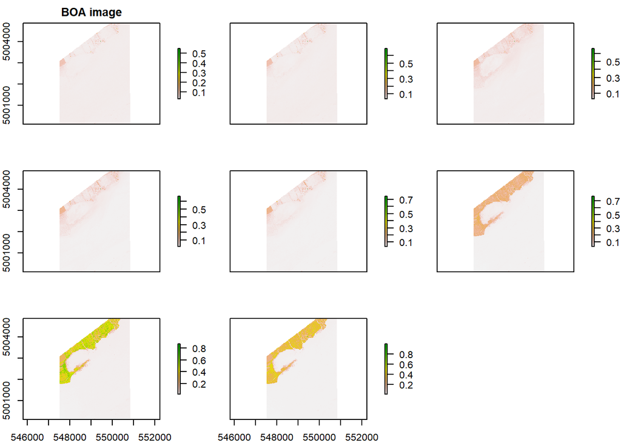

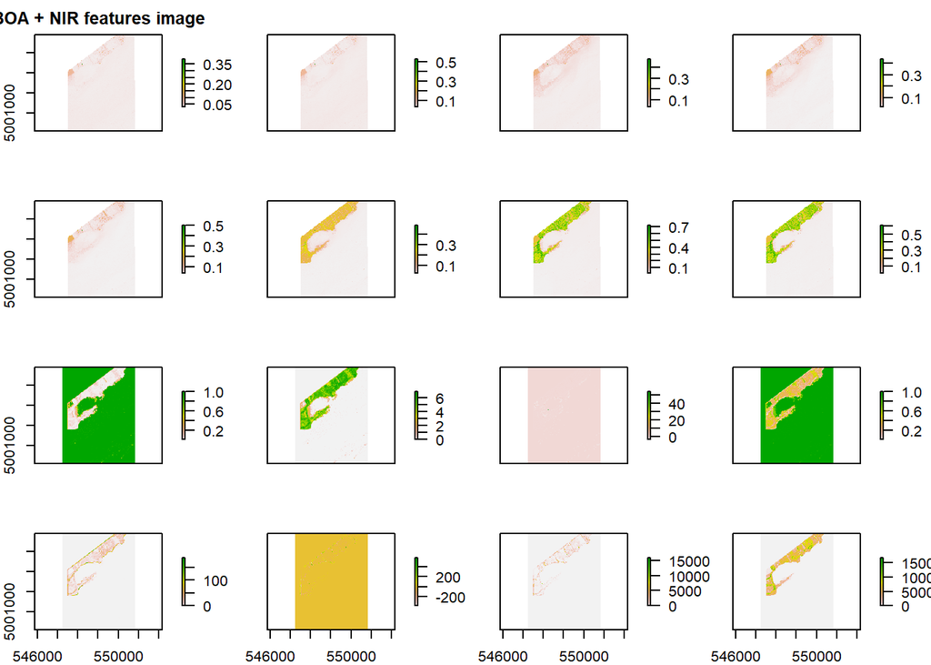

```r
final = dir(features_output, full.names = T, pattern=".tif")
plot(brick(MUL_input[1]), main = "BOA image"); plot(brick(final[1]), main = "BOA + NIR features image")
```

```r
brick(final[1])
```

```
## class      : RasterBrick
## dimensions : 2377, 2561, 6087497, 21  (nrow, ncol, ncell, nlayers)
## resolution : 1.41, 2  (x, y)
## extent     : 547220.6, 550831.6, 5000115, 5004869  (xmin, xmax, ymin, ymax)
## crs        : +proj=utm +zone=18 +datum=WGS84 +units=m +no_defs
## source     : C:/Users/Arthur/Documents/rscripts/Open_HRRS_W2/data/work/segmentation_output/features/2019-08-02_MUL_WV03_010577871010_01_P001.tif
## names      : X2019.08.//_01_P001.1, X2019.08.//_01_P001.2, X2019.08.//_01_P001.3, X2019.08.//_01_P001.4, X2019.08.//_01_P001.5, X2019.08.//_01_P001.6, X2019.08.//_01_P001.7, X2019.08.//_01_P001.8, X2019.08.//_01_P001.9, X2019.08.//01_P001.10, X2019.08.//01_P001.11, X2019.08.//01_P001.12, X2019.08…
## min values :          2.861805e-02,          1.150993e-02,          2.211644e-02,          5.769407e-03,          1.512197e-02,          7.610626e-03,          1.968668e-02,          1.043549e-02,          0.000000e+00,          0.000000e+00,         -6.886628e+00,          0.000000e+00,         …
## max values :          1.552772e+00,          1.375678e+00,          8.697162e-01,          8.013496e-01,          8.599402e-01,          9.301345e-01,          8.968782e-01,          1.167432e+00,          1.000000e+00,          7.151971e+00,          6.151681e+01,          1.000000e+00,         …
```

Now that the features have been extracted, we can proceed to classifications.